# Training the network of the Promoters experiment

Jaime Martínez Legaz

## Initial Setup

Loading all required libraries

```r
library(keras)
library(caret)
```

## Setting the data up

First we have to recover the treated data.

```r
SeqProm <- scan(file="Data/Promoters/SeqProm",what="character")
```

Now we face an issue with our sequences. They are 1250 characters long strings, but R sees them as indivisible elements. We have to transform them before working with them, turning each 1250 characters long sequence into 1250 sequences of only one character.

```r
posNum <- 715 # There are 715 positive sequences

n2 <- nchar(SeqProm[1]) -1 # Number of divisions to make

secuenciasOH <- sapply(1 + 1*0:n2, function(z) substr(SeqProm, z, z))  # Obtaining the split characters
df <- data.frame(secuenciasOH, "Value" = 0) # Saving them into a dataframe
indx <- sapply(df, is.factor)
df[indx] <- lapply(df[indx], function(x) as.character(x)) # Factor --> char conversion

df[1:posNum,]$Value <- 1 # We have the value of the positive sequences to positive
```

Now we have to divide our data into Training and Test for our model training. We will also check the proportions are the same as before the division.

```r
output <- c("Value")
partition <- createDataPartition(df[[output]],
                                      p = 0.8,
                                      list = FALSE,
                                      times = 1)

data.Train <- df[partition,]
data.Test <- df[-partition,]


# These all should be more or less the same
prop.table(table(data.Train$Value))*100
```

```
##
##        0        1
## 49.95648 50.04352
```

```r
prop.table(table(data.Test$Value))*100
```

```
##
##        0        1
## 51.21951 48.78049
```

```r
prop.table(table(df$Value))*100
```

```
##
##        0        1
## 50.20891 49.79109
```

Once divided, we have to adapt the data to the format the model expects.

```r
inData.Train.x <- data.matrix(data.Train[,1:1250])
inData.Train.y <- data.matrix(data.Train[,1251])

inData.Test.x <- data.matrix(data.Test[,1:1250])
inData.Test.y <- data.matrix(data.Test[,1251])

inData.Train.x <- array_reshape(inData.Train.x, c(nrow(data.Train), 1250, 1))
inData.Test.x <- array_reshape(inData.Test.x, c(nrow(data.Test), 1250, 1))
```

Now it is time to build our model. It follows the specifications mentioned in the thesis report.

```r
batch_size <- 10
epochs <- 120
input_shape <- c(1250,1)
learn_rate = 0.0003

set.seed(1337)

modelConvol <- keras_model_sequential()
  modelConvol %>%
  layer_conv_1d(filters = 30, kernel_size = 24, activation = "relu", input_shape = input_shape)%>%
  layer_conv_1d(filters = 30, kernel_size = 24, activation = "relu")%>%
  layer_max_pooling_1d() %>%
  layer_flatten() %>%
  layer_dense(units = 50, activation = 'relu') %>%
  layer_dense(units = 1, activation="sigmoid") %>% # 1

  summary(model)
```

```
## Model: "sequential"
## ________________________________________________________________________________
## Layer (type)                        Output Shape                    Param #
## ================================================================================
## conv1d (Conv1D)                     (None, 1227, 30)                750
## ________________________________________________________________________________
## conv1d_1 (Conv1D)                   (None, 1204, 30)                21630
## ________________________________________________________________________________
## max_pooling1d (MaxPooling1D)        (None, 602, 30)                 0
## ________________________________________________________________________________
## flatten (Flatten)                   (None, 18060)                   0
## ________________________________________________________________________________
## dense (Dense)                       (None, 50)                      903050
## ________________________________________________________________________________
## dense_1 (Dense)                     (None, 1)                       51
## ================================================================================
## Total params: 925,481
## Trainable params: 925,481
## Non-trainable params: 0
## ________________________________________________________________________________
```

```r
  modelConvol %>% compile(
  loss = loss_binary_crossentropy,
  optimizer = optimizer_nadam(lr = learn_rate),
  metrics = c('accuracy')
)
```

And now we train that model with the data obtained. After each training epoch, we will obtain certain statistics related to the sensitivity and specificity of the model, since they are not metrics that Keras can return from the model.

```r
  sens <- NULL
  spec <- NULL
  history <- NULL

for (epoch in 1:epochs){
  history <-
  c(history, modelConvol %>% fit(
  x = inData.Train.x,
  y = inData.Train.y,
  epochs = 1,
  batch_size = batch_size,
  validation_data = list(inData.Test.x, inData.Test.y),
  verbose = 2))

## Prediccion
pred <- modelConvol %>% predict(inData.Test.x, batch_size = batch_size)
prediction.y = round(pred)
# Confusion matrix
CM = table(prediction.y, inData.Test.y)
if (length(CM) > 2){
      sens <- c(sens,sensitivity(CM))
      spec <- c(spec,specificity(CM))
    }
    else {  # This happens in the weird cases the model only predicts positive or negative
      if (sum(grepl(0,prediction.y)) > 0){
        sens <- c(sens, 0)
        spec <- c(spec, 1)
      }
      else{
        sens <- c(sens, 0)
        spec <- c(spec, 1)
      }
    }
}
```

Lastly, we will plot the graphs showing the results of the training of this model.

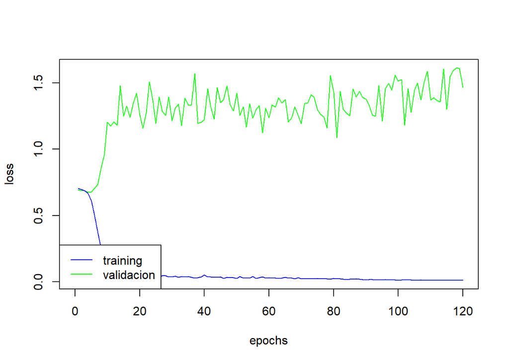

```r
nums <- NULL
nums <- (1:epochs)*2
valaccs <- NULL
accs <- NULL
valoss <- NULL
loss <- NULL
for (i in nums){
  valaccs <- c(valaccs,history[i]$metrics$val_acc)
  accs <- c(accs,history[i]$metrics$acc)
  loss <- c(loss,history[i]$metrics$loss)
  valoss <- c(valoss,history[i]$metrics$val_loss)
  }

plot(valoss, ylim = c(min(valoss,loss), max(valoss,loss)), cex = 0, xlim = c(0,epochs), ylab="loss", xlab="epochs")
lines(valoss, col="green")
lines(loss, col="blue")
legend("bottomleft", legend=c("training","validacion"), col=c("blue","green"), lty = 1)
```

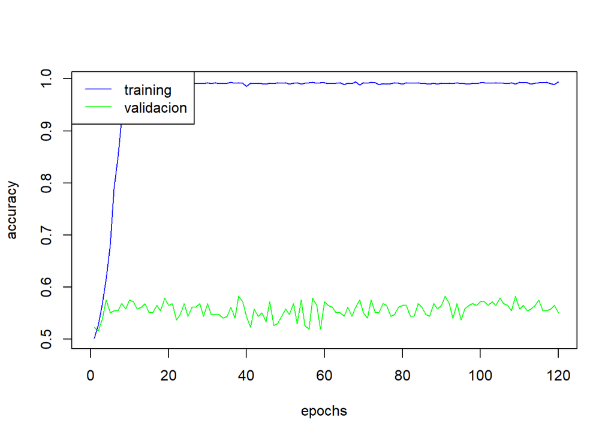

```r
plot(valaccs, ylim = c(min(valaccs,accs), max(valaccs,accs)), cex = 0, xlim = c(0,epochs), ylab = "accuracy", xlab = "epochs")
lines(valaccs, col="green")
lines(accs, col="blue")
legend("topleft", legend=c("training","validacion"), col=c("blue","green"), lty = 1)
```

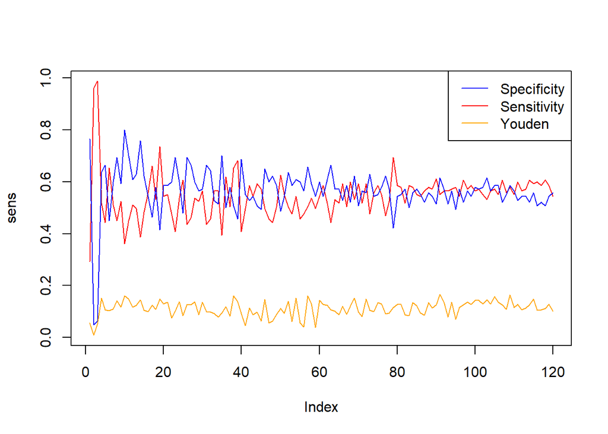

```r
plot(sens, ylim = c(min(sens, spec, sens + spec - 1), max(sens, spec, sens+spec-1)), cex = 0)
lines(sens,col="red")
lines(spec,col="blue")
lines((sens + spec) -1, col="orange")
legend("topright", legend=c("Specificity","Sensitivity", "Youden"), col=c("blue","red", "orange"), lty = 1)
```